# Performance assessment of IA-SVA using Brain scRNA-Seq data

Donghyung Lee & Duygu Ucar

2018-04-30

Here, we becnhmark several factor analyses methods on single cell RNA sequencing (scRNA-Seq) data obtained from human human brain samples ([Darmanis et. al., 2015](http://www.pnas.org/content/112/23/7285.long)). All of these methods are used to uncover variation associated with different cell types and compared against each other. This dataset is included in an R data package (“iasvaExamples”) containing data examples for IA-SVA (https://github.com/dleelab/iasvaExamples). To install the ‘iasvaExamples’ package, follow the instructions provided in the GitHub page.

## Load packages

```r
rm(list=ls())
library(iasva)
library(iasvaExamples)
library(sva)
library(RUVSeq)
```

```r
library(Rtsne)
library(pheatmap)
library(corrplot)
library(DescTools) #pcc i.e., Pearson's contingency coefficient
library(RColorBrewer)
library(zinbwave)
library(nnet)

color.vec <- brewer.pal(8, "Set1")

# Set you output directory
setwd("~/Dropbox/projects/IA-SVA/Darmanis_Brain")
set.seed(3532379)

# To make the task more challenging we selected 1000 genes to be used in downstream analyses.
num.genes <- 1000
```

## Load the brain single cell RNA-Seq data

```r
data("Darmanis_Brain_scRNAseq_Read_Counts")
data("Darmanis_Brain_scRNAseq_Annotations")
ls()
```

```
## [1] "color.vec"
## [2] "Darmanis_Brain_scRNAseq_Annotations"
## [3] "Darmanis_Brain_scRNAseq_Read_Counts"
## [4] "num.genes"
```

```r
counts.total <- Darmanis_Brain_scRNAseq_Read_Counts
anns.total <- Darmanis_Brain_scRNAseq_Annotations
dim(anns.total)
```

```
## [1] 461   6
```

```r
dim(counts.total)
```

```
## [1] 23267   461
```

```r
summary(anns.total)
```

```
##          run              tissue                cell_type
##  SRR1974543:  1   cortex     :426   neurons          :129
##  SRR1974544:  1   hippocampus: 35   fetal_quiescent  :109
##  SRR1974545:  1                     astrocytes       : 62
##  SRR1974546:  1                     hybrid           : 46
##  SRR1974547:  1                     oligodendrocytes : 37
##  SRR1974548:  1                     fetal_replicating: 25
##  (Other)   :455                     (Other)          : 53
##                  age           c1_chip_id   sample_name
##  prenatal 16-18 W  :133   nochipID2 : 77   AB_S4  : 77
##  postnatal 50 years: 77   nochipID8 : 55   AB_S11 : 62
##  postnatal 37 years: 62   nochipID11: 45   AB_S8  : 57
##  postnatal 54 years: 57   1772078217: 33   AB_S7  : 55
##  postnatal 21 years: 55   1772078236: 33   FB_S2  : 45
##  postnatal 63 years: 49   nochipID13: 33   AB_S5  : 44
##  (Other)           : 28   (Other)   :185   (Other):121
```

```r
table(anns.total$tissue, anns.total$cell_type)
```

```
##
##               astrocytes endothelial fetal_quiescent fetal_replicating
##   cortex              62          17             109                25
##   hippocampus          0           3               0                 0
##
##               hybrid microglia neurons oligodendrocytes OPC
##   cortex          44         8     128               31   2
##   hippocampus      2         7       1                6  16
```

```r
ContCoef(table(anns.total$tissue, anns.total$cell_type))
```

```
## [1] 0.5794563
```

```r
table(anns.total$age, anns.total$cell_type)
```

```
##
##                      astrocytes endothelial fetal_quiescent
##   postnatal 21 years          3           0               0
##   postnatal 22 years          0           1               1
##   postnatal 37 years          7           1               0
##   postnatal 47 years         11           2               0
##   postnatal 50 years         38           0               0
##   postnatal 54 years          1           0               0
##   postnatal 63 years          2          16               0
##   prenatal 16-18 W            0           0             108
##
##                      fetal_replicating hybrid microglia neurons
##   postnatal 21 years                 0      7         0      34
##   postnatal 22 years                 0      0         0       2
##   postnatal 37 years                 0      3         1      49
##   postnatal 47 years                 0      0         5       6
##   postnatal 50 years                 0     19         0      19
##   postnatal 54 years                 0     17         6       0
##   postnatal 63 years                 0      0         3      19
##   prenatal 16-18 W                  25      0         0       0
##
##                      oligodendrocytes OPC
##   postnatal 21 years               11   0
##   postnatal 22 years                0   0
##   postnatal 37 years                1   0
##   postnatal 47 years                0   0
##   postnatal 50 years                1   0
##   postnatal 54 years               15  18
##   postnatal 63 years                9   0
##   prenatal 16-18 W                  0   0
```

```r
ContCoef(table(anns.total$age, anns.total$cell_type))
```

```
## [1] 0.8256324
```

```r
table(anns.total$sample_name, anns.total$cell_type)
```

```
##
##          astrocytes endothelial fetal_quiescent fetal_replicating hybrid
##   AB_S1          11           2               0                 0      0
##   AB_S11          7           1               0                 0      3
##   AB_S2           2           0               0                 0      0
##   AB_S3           0           1               1                 0      0
##   AB_S4          38           0               0                 0     19
##   AB_S5           0          16               0                 0      0
##   AB_S7           3           0               0                 0      7
##   AB_S8           1           0               0                 0     17
##   FB_S1           0           0               5                21      0
##   FB_S2           0           0              43                 2      0
##   FB_S3           0           0              33                 0      0
##   FB_S6           0           0              27                 2      0
##
##          microglia neurons oligodendrocytes OPC
##   AB_S1          5       6                0   0
##   AB_S11         1      49                1   0
##   AB_S2          2       1                0   0
##   AB_S3          0       2                0   0
##   AB_S4          0      19                1   0
##   AB_S5          1      18                9   0
##   AB_S7          0      34               11   0
##   AB_S8          6       0               15  18
##   FB_S1          0       0                0   0
##   FB_S2          0       0                0   0
##   FB_S3          0       0                0   0
##   FB_S6          0       0                0   0
```

```r
ContCoef(table(anns.total$sample_name, anns.total$cell_type))
```

```
## [1] 0.8602264
```

```r
table(anns.total$c1_chip_id, anns.total$cell_type)
```

```
##
##              astrocytes endothelial fetal_quiescent fetal_replicating
##   1772078217          1           0               0                 0
##   1772078218          0           0               0                 0
##   1772078236          2           0               0                 0
##   1772078237          5           1               0                 0
##   nochipID10          0           0               5                21
##   nochipID11          0           0              43                 2
##   nochipID12          1           2               0                 0
##   nochipID13          0           0              33                 0
##   nochipID14          2           0               0                 0
##   nochipID15          0           1               1                 0
##   nochipID2          38           0               0                 0
##   nochipID3           0          13               0                 0
##   nochipID4           0           0              27                 2
##   nochipID5           0           3               0                 0
##   nochipID8           3           0               0                 0
##   nochipID9          10           0               0                 0
##
##              hybrid microglia neurons oligodendrocytes OPC
##   1772078217     15         0       0               15   2
##   1772078218      2         6       0                0  16
##   1772078236      3         1      26                1   0
##   1772078237      0         0      23                0   0
##   nochipID10      0         0       0                0   0
##   nochipID11      0         0       0                0   0
##   nochipID12      0         2       0                0   0
##   nochipID13      0         0       0                0   0
##   nochipID14      0         2       1                0   0
##   nochipID15      0         0       2                0   0
##   nochipID2      19         0      19                1   0
##   nochipID3       0         0      17                3   0
##   nochipID4       0         0       0                0   0
##   nochipID5       0         1       1                6   0
##   nochipID8       7         0      34               11   0
##   nochipID9       0         3       6                0   0
```

```r
ContCoef(table(anns.total$c1_chip_id, anns.total$cell_type))
```

```
## [1] 0.8802176
```

The annotations describing samples and experimental settings are stored in “anns” and the read counts information is stored in “counts”.

```r
# Select neurons and astrocytes for downstream analyses
selected.cells <- intersect(which(anns.total$tissue=="cortex"), which(anns.total$cell_type=="neurons"|anns.total$cell_type=="astrocytes"))
counts <- counts.total[, selected.cells]
anns <- droplevels(anns.total[selected.cells,])

table(anns$tissue, anns$cell_type)
```

```
     astrocytes neurons
```

cortex 62 128

```r
table(anns$tissue, anns$age)
```

```
     postnatal 21 years postnatal 22 years postnatal 37 years
```

cortex 37 2 56

```
     postnatal 47 years postnatal 50 years postnatal 54 years
```

cortex 17 57 1

```
     postnatal 63 years
```

cortex 20

```r
table(anns$age, anns$sample_name)
```

```
                 AB_S1 AB_S11 AB_S2 AB_S3 AB_S4 AB_S5 AB_S7 AB_S8
```

postnatal 21 years 0 0 0 0 0 0 37 0 postnatal 22 years 0 0 0 2 0 0 0 0 postnatal 37 years 0 56 0 0 0 0 0 0 postnatal 47 years 17 0 0 0 0 0 0 0 postnatal 50 years 0 0 0 0 57 0 0 0 postnatal 54 years 0 0 0 0 0 0 0 1 postnatal 63 years 0 0 3 0 0 17 0 0

```r
table(anns$age, anns$c1_chip_id)
```

```
                 1772078217 1772078236 1772078237 nochipID12
```

postnatal 21 years 0 0 0 0 postnatal 22 years 0 0 0 0 postnatal 37 years 0 28 28 0 postnatal 47 years 0 0 0 1 postnatal 50 years 0 0 0 0 postnatal 54 years 1 0 0 0 postnatal 63 years 0 0 0 0

```
                 nochipID14 nochipID15 nochipID2 nochipID3 nochipID8
```

postnatal 21 years 0 0 0 0 37 postnatal 22 years 0 2 0 0 0 postnatal 37 years 0 0 0 0 0 postnatal 47 years 0 0 0 0 0 postnatal 50 years 0 0 57 0 0 postnatal 54 years 0 0 0 0 0 postnatal 63 years 3 0 0 17 0

```
                 nochipID9
```

postnatal 21 years 0 postnatal 22 years 0 postnatal 37 years 0 postnatal 47 years 16 postnatal 50 years 0 postnatal 54 years 0 postnatal 63 years 0

```r
table(anns$tissue, anns$c1_chip_id)
```

```
     1772078217 1772078236 1772078237 nochipID12 nochipID14 nochipID15
```

cortex 1 28 28 1 3 2

```
     nochipID2 nochipID3 nochipID8 nochipID9
```

cortex 57 17 37 16

```r
table(anns$cell_type, anns$sample_name)
```

```
         AB_S1 AB_S11 AB_S2 AB_S3 AB_S4 AB_S5 AB_S7 AB_S8
```

astrocytes 11 7 2 0 38 0 3 1 neurons 6 49 1 2 19 17 34 0

```r
table(anns$cell_type, anns$tissue)
```

```
         cortex
```

astrocytes 62 neurons 128

```r
dim(counts)
```

[1] 23267 190

```r
dim(anns)
```

[1] 190 6

```r
dropout.rate <- sum(counts==0)/(dim(counts)[1]*dim(counts)[2])*100
dropout.rate
```

[1] 66.32653

```r
## Filter out lowly-expressed genes
filter = apply(counts, 1, function(x) length(x[x>5])>=3)
counts = as.matrix(counts[filter,])
dim(counts)
```

[1] 21806 190

```r
dropout.rate <- sum(counts==0)/(dim(counts)[1]*dim(counts)[2])*100
dropout.rate
```

[1] 64.13206

```r
# To make this task more challenging for benchamarking purposes
# we only used randomly selected 1000 genes in downstream analyses
rand.gene.list <- sample(1:nrow(counts), num.genes)
counts <- counts[rand.gene.list,]

Cell_Type <- anns$cell_type
Tissue <- anns$tissue
Cell_Type_Num <- as.integer(Cell_Type)
Samples <- as.integer(anns$sample_name)
```

## Calculate geometric library size, i.e., library size of log-transfromed read counts

It is well known that the geometric library size (i.e., library size of log-transfromed read counts) or proportion of expressed genes in each cell explains very large portion of variability of scRNA-Seq data ([Hicks et. al. 2015 BioRxiv](http://biorxiv.org/content/early/2015/08/25/025528), [McDavid et. al. 2016 Nature Biotechnology](http://www.nature.com/nbt/journal/v34/n6/full/nbt.3498.html)). Frequently, the first principal component of log-transformed scRNA-Seq read counts is highly correlated with the geometric library size. (r > 0.9). Here, we calculate it and show the high correlation. Later this vector will be used as an known factor in IA-SVA algorithm.

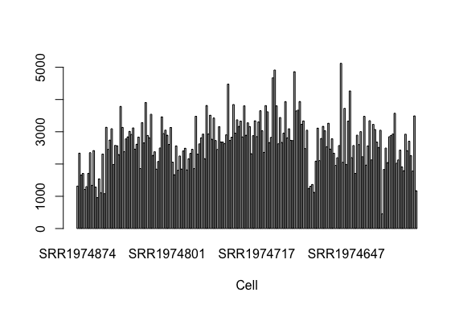

```r
Geo_Lib_Size <- colSums(log(counts+1))
barplot(Geo_Lib_Size, xlab="Cell")
```

```r
lcounts <- log(counts + 1)
pca.res = svd(lcounts - rowMeans(lcounts))$v
cor(Geo_Lib_Size, pca.res[,1])
```

```
## [1] 0.9435376
```

```r
cor(Geo_Lib_Size, Cell_Type_Num)
```

```
## [1] 0.1815641
```

## run analyses

```r
mod1 = model.matrix(~Geo_Lib_Size+anns$sample_name)
mod0 = cbind(mod1[,1])

###Estimate Hidden factors using different methods

### IA-SVA
start_time <- Sys.time()
iasva.res<- iasva(t(counts), mod1[,-1],verbose=FALSE, permute=FALSE, num.sv=3)
```

```
## IA-SVA running...
## SV1 Detected!
## SV2 Detected!
## SV3 Detected!
## # of significant surrogate variables: 3
```

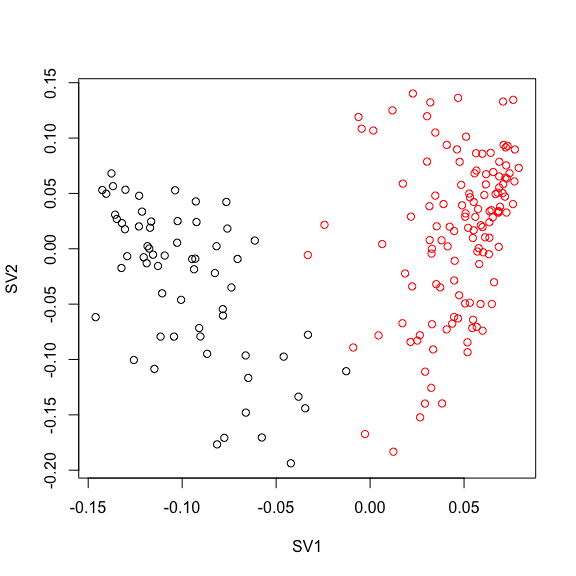

```r
end_time <- Sys.time()
iasva.time <- start_time - end_time
iasva.sv <- iasva.res$sv
plot(iasva.sv[,1], iasva.sv[,2],col=Cell_Type, xlab="SV1", ylab="SV2")
```

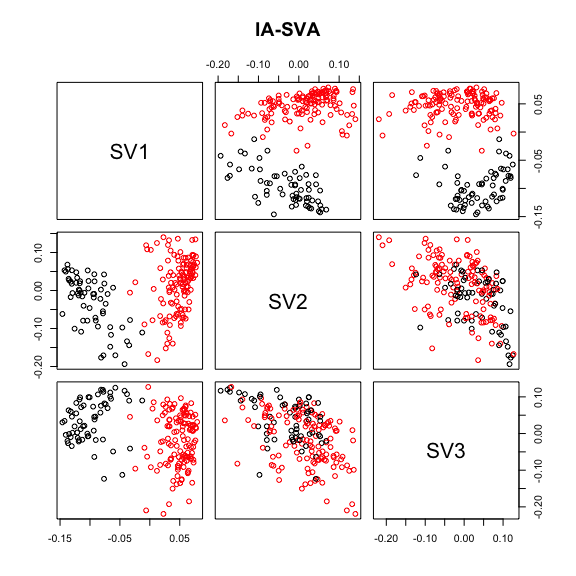

```r
pairs(iasva.sv, col=Cell_Type, main="IA-SVA")
```

```r
max.cor.iasva <- which.is.max(c(abs(cor(iasva.sv[,1], Cell_Type_Num)),
                abs(cor(iasva.sv[,2], Cell_Type_Num)),
                abs(cor(iasva.sv[,3], Cell_Type_Num))))
max.cor.iasva
```

```
## [1] 1
```

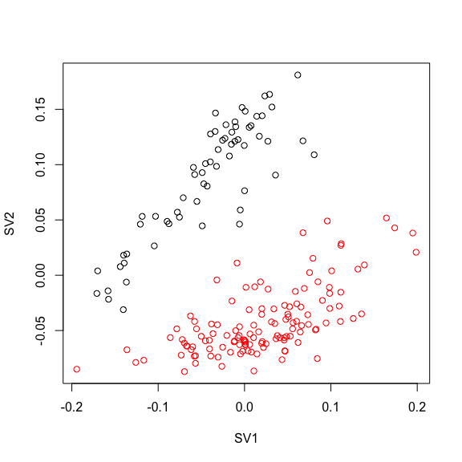

```r
## PCA
ldat0 = log(counts + 1)
start_time <- Sys.time()
pca.sv = svd(ldat0 - rowMeans(ldat0))$v
end_time <- Sys.time()
pca.time <- start_time - end_time
plot(pca.sv[,1], pca.sv[,2],col=Cell_Type, xlab="SV1", ylab="SV2")
```

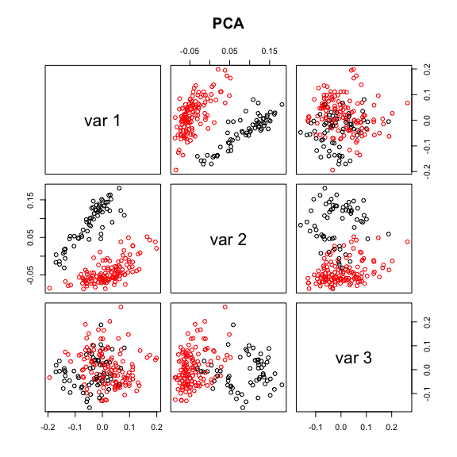

```r
pairs(pca.sv[,1:3], col=Cell_Type, main="PCA")
```

```r
max.cor.pca <- which.is.max(c(abs(cor(pca.sv[,1], Cell_Type_Num)),
                abs(cor(pca.sv[,2], Cell_Type_Num)),
                abs(cor(pca.sv[,3], Cell_Type_Num))))
max.cor.pca
```

```
## [1] 2
```

```r
## USVA
start_time <- Sys.time()
usva.sv = svaseq(counts,mod1,mod0,n.sv=3)$sv
```

```
## Number of significant surrogate variables is:  3
## Iteration (out of 5 ):1  2  3  4  5
```

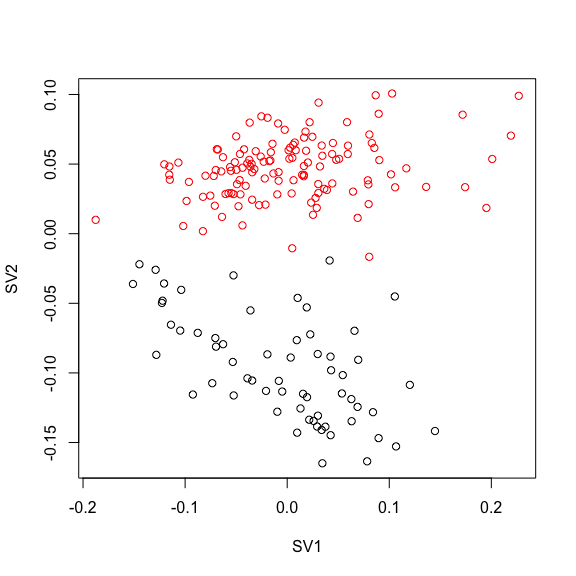

```r
end_time <- Sys.time()
usva.time <- start_time - end_time
plot(usva.sv[,1], usva.sv[,2],col=Cell_Type, xlab="SV1", ylab="SV2")
```

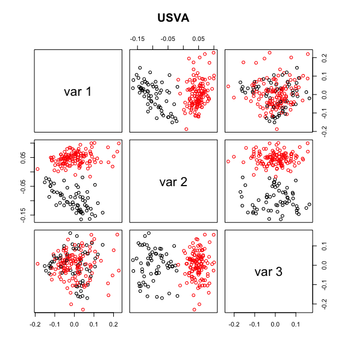

```r
pairs(usva.sv[,1:3], col=Cell_Type, main="USVA")
```

```r
max.cor.usva <- which.is.max(c (abs(cor(usva.sv[,1], Cell_Type_Num)),
                abs(cor(usva.sv[,2], Cell_Type_Num)),
                abs(cor(usva.sv[,3], Cell_Type_Num))))
max.cor.usva
```

```
## [1] 2
```

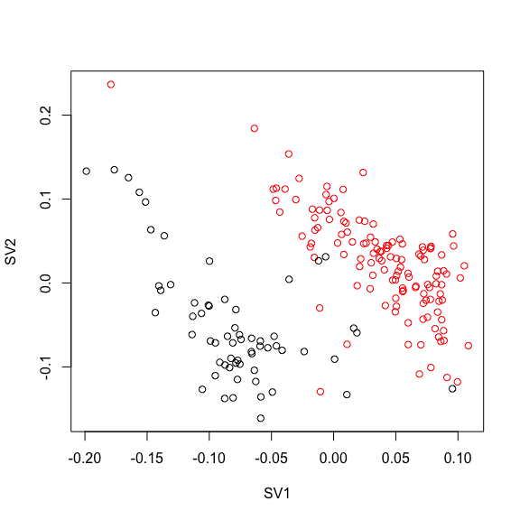

```r
### RUVres
#x <- as.factor(Tissue)
design <- model.matrix(~Geo_Lib_Size+anns$sample_name)
start_time <- Sys.time()
y <- DGEList(counts=counts)
y <- calcNormFactors(y, method="TMM")
y <- estimateGLMCommonDisp(y, design)
y <- estimateGLMTagwiseDisp(y, design)
fit <- glmFit(y, design)
res <- residuals(fit, type="deviance")
set <- betweenLaneNormalization(counts, which="upper")
genes = rep(TRUE,dim(counts)[1])
ruvres.sv = RUVr(set,genes,k=3,res,isLog = T)$W
end_time <- Sys.time()
ruvres.time <- start_time - end_time
plot(ruvres.sv[,1], ruvres.sv[,2],col=Cell_Type, xlab="SV1", ylab="SV2")
```

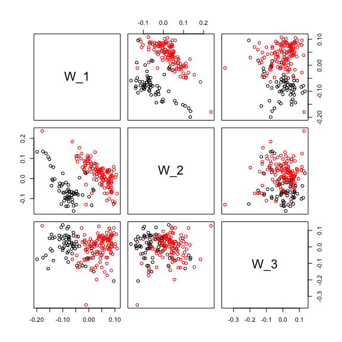

```r
pairs(ruvres.sv[,1:3], col=Cell_Type)
```

```r
max.cor.ruvres <- which.is.max (c (abs(cor(ruvres.sv[,1], Cell_Type_Num)),
                abs(cor(ruvres.sv[,2], Cell_Type_Num)),
                abs(cor(ruvres.sv[,3], Cell_Type_Num))))
max.cor.ruvres
```

```
## [1] 1
```

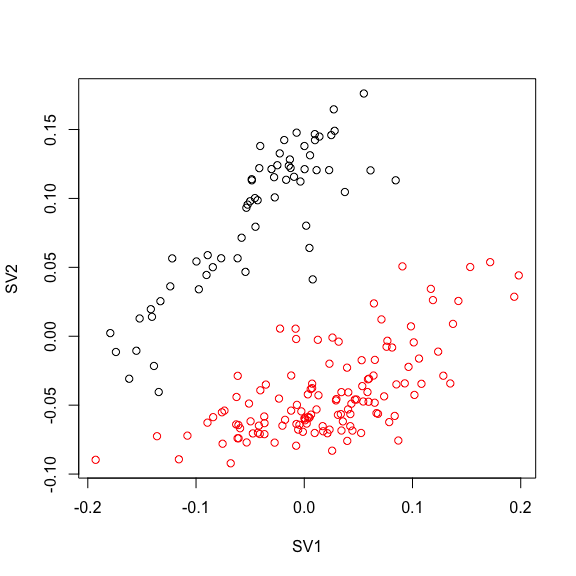

```r
### RUVemp
start_time <- Sys.time()
y <- DGEList(counts=counts)
y <- calcNormFactors(y, method="TMM")
y <- estimateGLMCommonDisp(y, design)
y <- estimateGLMTagwiseDisp(y, design)
fit <- glmFit(y, design)
lrt <- glmLRT(fit, coef=2)
emp.genes =rank(lrt$table$LR) > 400
ruvemp.sv <- RUVg(counts, emp.genes, k=3)$W
end_time <- Sys.time()
ruvemp.time <- start_time - end_time
plot(ruvemp.sv[,1], ruvemp.sv[,2],col=Cell_Type, xlab="SV1", ylab="SV2")
```

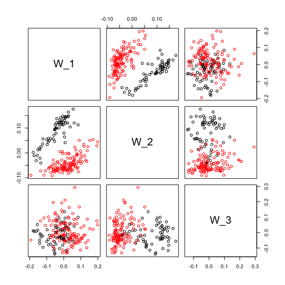

```r
pairs(ruvemp.sv[,1:3], col=Cell_Type)
```

```r
max.cor.ruvemp <- which.is.max(c (abs(cor(ruvemp.sv[,1], Cell_Type_Num)),
                abs(cor(ruvemp.sv[,2], Cell_Type_Num)),
                abs(cor(ruvemp.sv[,3], Cell_Type_Num))))
max.cor.ruvemp
```

```
## [1] 2
```

```r
### ZINB WAVE
se.data <- SummarizedExperiment(assays=list(counts=counts))
se.data$LS <- Geo_Lib_Size
se.data$SN <- anns$sample_name
se.data$Tissue <- anns$tissue
# use Geometric library size + Tissue + sample is as covariates
# suggested epsilon parameter is used for the analyses
start_time <- Sys.time()
zinb_cov <- zinbFit(se.data, K=3, X="~LS+SN", epsilon=1000)
```

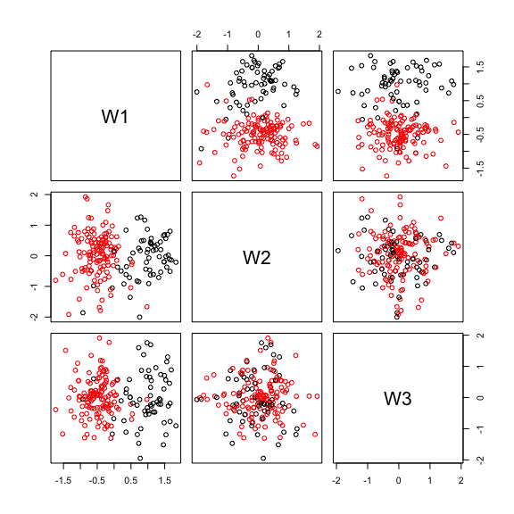

```r
W <- getW(zinb_cov)
end_time <- Sys.time()
zinb.time <- start_time - end_time
colnames(W) <- paste0("W", 1:3)
pairs(W,col=Cell_Type)
```

```r
max.cor.zinb <- which.is.max (c (abs(cor(W[,1], Cell_Type_Num)),
                abs(cor(W[,2], Cell_Type_Num)),
                abs(cor(W[,3], Cell_Type_Num))))

max.cor.zinb
```

```
## [1] 1
```

## Compare results

Compare results from different methods to the true cell type assignments using correlation plots.

```r
## Plot correlation between true cell_type and estimates (SV1)
celltype.est = cbind(Cell_Type_Num, iasva.sv[,max.cor.iasva],pca.sv[,max.cor.pca],usva.sv[,max.cor.usva], ruvres.sv[,max.cor.ruvres], ruvemp.sv[,max.cor.ruvemp], W[,max.cor.zinb])

colnames(celltype.est) = c("Cell Type","IA-SVA","PCA","USVA","RUVres","RUVemp", "ZINB-WAVE")
corr = abs(cor(celltype.est))
print(corr)
```

```
##           Cell Type    IA-SVA       PCA      USVA    RUVres    RUVemp
## Cell Type 1.0000000 0.9364864 0.8412577 0.9217416 0.7647545 0.8358981
## IA-SVA    0.9364864 1.0000000 0.9241849 0.9441659 0.7767147 0.9186404
## PCA       0.8412577 0.9241849 1.0000000 0.8876566 0.5462038 0.9959706
## USVA      0.9217416 0.9441659 0.8876566 1.0000000 0.7562104 0.8756892
## RUVres    0.7647545 0.7767147 0.5462038 0.7562104 1.0000000 0.5373816
## RUVemp    0.8358981 0.9186404 0.9959706 0.8756892 0.5373816 1.0000000
## ZINB-WAVE 0.8255676 0.8472393 0.8045799 0.8615873 0.6648695 0.7891535
##           ZINB-WAVE
## Cell Type 0.8255676
## IA-SVA    0.8472393
## PCA       0.8045799
## USVA      0.8615873
## RUVres    0.6648695
## RUVemp    0.7891535
## ZINB-WAVE 1.0000000
```

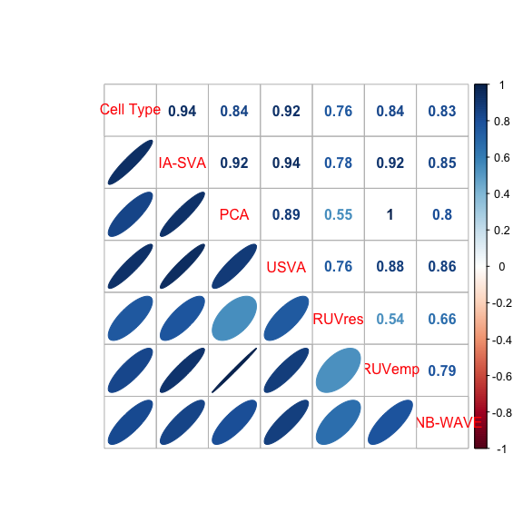

```r
cols = colorRampPalette(c(color.vec[2],"white",color.vec[1]))

corrplot.mixed(corr, lower="ellipse", upper="number", mar=c(0,0,1,0))
```

```r
num.cells <- dim(anns)[1]
pdf(paste0("Brain_scRNASeq_neuron_astro_",num.cells,"_cells.pdf"), height=6, width=6)
corrplot.mixed(corr, lower="ellipse", upper="number", mar=c(0,0,1,0))
dev.off()
```

```r
time.seconds <- c(iasva.time,pca.time,usva.time,ruvres.time,ruvemp.time,zinb.time)
names(time.seconds) <- c("IA-SVA","PCA","USVA","RUVres","RUVemp", "ZINB-WAVE")
time.seconds
```

```
## Time differences in secs
##     IA-SVA        PCA       USVA     RUVres     RUVemp  ZINB-WAVE
##  -0.721899  -0.120744  -1.166319 -74.556122 -73.483445 -57.829675
```

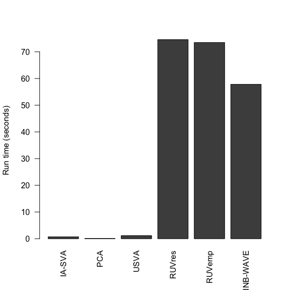

```r
barplot(t(as.matrix(abs(time.seconds))), las =2, ylab = "Run time (seconds)")
```

```r
pdf(paste0("Brain_scRNASeq_neuron_astro_",num.cells,"_cells_run_time.pdf"), height=6, width=6)
barplot(t(as.matrix(abs(time.seconds))), las =2, ylab = "Run time (seconds)")
dev.off()
```